# Week #2: MLM

Zoë Hawks

9/10/2017

## Importing data

```r
setwd("/Users/zashawks/Desktop/PNL/PKU/Verbal Fluency/")
mydata_wide <- read.csv("VerbalFluency_StrategicProcessing.csv", header=TRUE)
mydata_long <- read.csv("NJ_data_3.csv")
mydata_dob <- read.csv("IQ_VF_participants.csv")

setwd("/Users/zashawks/Desktop/Stats/Longitudinal/ALDA")
library(tidyverse)
library(tibble)
library(lubridate)
```

## Setting up dataframe

```r
mydata_dob2 <- mydata_dob %>%
  select(IDNUMBER, GENDER, GROUP, L1dob, L1age, L1dot,
         L2dob, L2age, L2dot, L3dob, L3age, L3dot) %>%
  mutate_at(c(4, 6, 7, 9, 10, 12), as.character) %>%
  rename(ID2 = IDNUMBER, L1_dob = L1dob, L1_age = L1age, L1_dot = L1dot,
         L2_dob = L2dob, L2_age = L2age, L2_dot = L2dot, L3_dob = L3dob, L3_age = L3age, L3_dot = L3dot)

mydata_merged <- left_join(mydata_wide, mydata_dob2)
wide_to_long2 <- mydata_merged %>%
  gather(-ID2, -GENDER, -GROUP, key = "timepoint", value = "value") %>%
  separate(timepoint, into = c("Omit", "Timepoint", "Omit2", "Variable"), sep = c(1,2, 3)) %>%
  select(-Omit, -Omit2) %>%
  spread(key = Variable, value = value) %>%
  drop_na() %>%
  mutate(dob = mdy(dob), dot = mdy(dot))
wide_to_long2 <- wide_to_long2[1:200, ]

mydata_dob2$baselinedate <- mydata_dob2$L1_dot
wide_to_long3 <- mydata_dob2 %>%
  gather(-ID2, -GENDER, -GROUP, -baselinedate, key = "timepoint", value = "value") %>%
  separate(timepoint, into = c("Omit", "Timepoint", "Omit2", "Variable"), sep = c(1,2, 3)) %>%
  select(-Omit, -Omit2) %>%
  spread(key = Variable, value = value) %>%
  drop_na() %>%
  mutate(dob = mdy(dob), dot = mdy(dot), baselinedate = mdy(baselinedate))

wide_to_long_merged <- full_join(wide_to_long2, wide_to_long3)
wide_to_long_merged <- as_tibble(wide_to_long_merged)
wide_to_long_merged
```

```
## # A tibble: 272 x 22
##      ID2 GENDER GROUP Timepoint              age all_TC all_TU
##    <int>  <int> <int>     <chr>            <chr>  <chr>  <chr>
##  1 10588      1     2         1 18.9189530057522  23.75   26.5
##  2 10588      1     2         2               20     28   31.5
##  3 16800      2     2         1 8.58334553878917  11.25   12.5
##  4 16800      2     2         2               10  16.75   20.5
##  5 16800      2     2         3               11   26.5     34
##  6 17555      2     2         1 17.5636879206802  20.25   22.5
##  7 17555      2     2         2               18  17.75  20.25
##  8 17555      2     2         3               20     40     45
##  9 17910      1     1         1 11.5731424537358  14.25  17.75
## 10 17910      1     1         2               13     17     23
## # ... with 262 more rows, and 15 more variables:
## #   animal_TotalCorrect <chr>, animal_TotalUtterances <chr>, dob <date>,
## #   dot <date>, f_TotalCorrect <chr>, f_TotalUtterances <chr>,
## #   food_TotalCorrect <chr>, food_TotalUtterances <chr>, pho_TC <chr>,
## #   pho_TU <chr>, S_TotalCorrect <chr>, S_TotalUtterances <chr>,
## #   sem_TC <chr>, sem_TU <chr>, baselinedate <date>
```

```r
#Converting date
#Age
wide_to_long_merged$Age_days <- round(as.duration(wide_to_long_merged$dob %--%
                                                    wide_to_long_merged$dot)/ddays(1), 1)
wide_to_long_merged$Age_weeks <- round(as.duration(wide_to_long_merged$dob %--%
                                                     wide_to_long_merged$dot)/dweeks(1), 1)
wide_to_long_merged$Age_years <- round(as.duration(wide_to_long_merged$dob %--%
                                                     wide_to_long_merged$dot)/dyears(1), 1)

#Time in study
wide_to_long_merged$TIS_days <- round(as.duration(wide_to_long_merged$baselinedate %--%
                                                    wide_to_long_merged$dot)/ddays(1))
wide_to_long_merged$TIS_weeks <- round(as.duration(wide_to_long_merged$baselinedate %--%
                                                     wide_to_long_merged$dot)/dweeks(1))
wide_to_long_merged$TIS_years <- round(as.duration(wide_to_long_merged$baselinedate %--%
                                                     wide_to_long_merged$dot)/dyears(1))

#Adjust type
wide_to_long_merged$GENDER <- as.factor(wide_to_long_merged$GENDER)
wide_to_long_merged$GROUP <- as.factor(wide_to_long_merged$GROUP)
wide_to_long_merged$age <- as.numeric(wide_to_long_merged$age)
wide_to_long_merged$animal_TotalCorrect <- as.numeric(wide_to_long_merged$animal_TotalCorrect)
wide_to_long_merged$food_TotalCorrect <- as.numeric(wide_to_long_merged$food_TotalCorrect)

levels(wide_to_long_merged$GROUP)[levels(wide_to_long_merged$GROUP)==2] <- "Controls"
levels(wide_to_long_merged$GROUP)[levels(wide_to_long_merged$GROUP)==1] <- "PKU"

wide_to_long_merged$Sem_TotalCorrect <- (wide_to_long_merged$animal_TotalCorrect +
                                           wide_to_long_merged$food_TotalCorrect)
```

## Item 1: Run linear models on all of your subjects (a basic regression). What is the average intercept, the average slope?

```r
wide_to_long_merged$age.centered <- wide_to_long_merged$age - mean(wide_to_long_merged$age, na.rm = T)

lin.mod <- lm(Sem_TotalCorrect ~ age.centered, data = wide_to_long_merged)
summary(lin.mod)
```

```
##
## Call:
## lm(formula = Sem_TotalCorrect ~ age.centered, data = wide_to_long_merged)
##
## Residuals:
##     Min      1Q  Median      3Q     Max
## -18.958  -5.497  -0.716   5.288  29.223
##
## Coefficients:
##              Estimate Std. Error t value Pr(>|t|)
## (Intercept)   39.5020     0.6054  65.246   <2e-16 ***
## age.centered   1.6968     0.1828   9.284   <2e-16 ***
## ---
## Signif. codes:  0 '***' 0.001 '**' 0.01 '*' 0.05 '.' 0.1 ' ' 1
##
## Residual standard error: 8.461 on 198 degrees of freedom
##   (72 observations deleted due to missingness)
## Multiple R-squared:  0.3033, Adjusted R-squared:  0.2998
## F-statistic:  86.2 on 1 and 198 DF,  p-value: < 2.2e-16
```

```r
anova(lin.mod)
```

```
## Analysis of Variance Table
##
## Response: Sem_TotalCorrect
##               Df  Sum Sq Mean Sq F value    Pr(>F)
## age.centered   1  6170.4  6170.4  86.197 < 2.2e-16 ***
## Residuals    198 14173.7    71.6
## ---
## Signif. codes:  0 '***' 0.001 '**' 0.01 '*' 0.05 '.' 0.1 ' ' 1
```

```r
summary <- broom::glance(lin.mod)
Resid.var <- summary[1,3]^2
Resid.var
```

```
## [1] 71.58436
```

Average intercept = 39.50 corrects words (at mean age)  
Average slope = 1.70 correct words/year  
Residual variance = 71.58  
___

## Item 2: Now run a mlm/lmer model with only a random intercept. What is the ICC? What does residual variance look like compared to linear model? Create a graph to show this effect.

```r
library(lme4)
```

```r
library(stats)
library(ggplot2)

lin.mlm <- lmer(Sem_TotalCorrect ~ (1 | ID2), data = wide_to_long_merged)
summary(lin.mlm)
```

```
## Linear mixed model fit by REML ['lmerMod']
## Formula: Sem_TotalCorrect ~ (1 | ID2)
##    Data: wide_to_long_merged
##
## REML criterion at convergence: 1449.1
##
## Scaled residuals:
##      Min       1Q   Median       3Q      Max
## -2.05419 -0.55293 -0.06226  0.56106  2.63259
##
## Random effects:
##  Groups   Name        Variance Std.Dev.
##  ID2      (Intercept) 50.81    7.128
##  Residual             52.95    7.277
## Number of obs: 200, groups:  ID2, 67
##
## Fixed effects:
##             Estimate Std. Error t value
## (Intercept)   38.717      1.012   38.27
```

```r
lin.mlm.ci1 <- confint(lin.mlm, level = .95, oldNames = F)
```

```
## Computing profile confidence intervals ...
```

```r
lin.mlm.ci1
```

```
##                        2.5 %    97.5 %
## sd_(Intercept)|ID2  5.508187  8.915312
## sigma               6.479868  8.253210
## (Intercept)        36.721203 40.714879
```

```r
summary1 <- broom::tidy(lin.mlm)
summary1
```

```
##                      term  estimate std.error statistic    group
## 1             (Intercept) 38.716534  1.011669  38.26995    fixed
## 2      sd_(Intercept).ID2  7.127811        NA        NA      ID2
## 3 sd_Observation.Residual  7.276727        NA        NA Residual
```

```r
ICC.mlm <- summary1[2,2]^2/(summary1[2,2]^2 + summary1[3,2]^2)
ICC.mlm
```

```
## [1] 0.489663
```

```r
#plotting residuals
mlm.aug <- abs(broom::augment(lin.mlm)[,c(4)])
head(mlm.aug)
```

```
## [1] 7.9765792 7.9765792 6.7213043 0.2786957 2.2786957 0.6200895
```

```r
mean.mlm = mean(mlm.aug)
sd.mlm = sd(mlm.aug)

lin.aug <- abs(broom::augment(lin.mod)[,5])
head(lin.aug)
```

```
## [1] 13.482650 11.648303  2.979638  1.616548  1.919724  2.217703
```

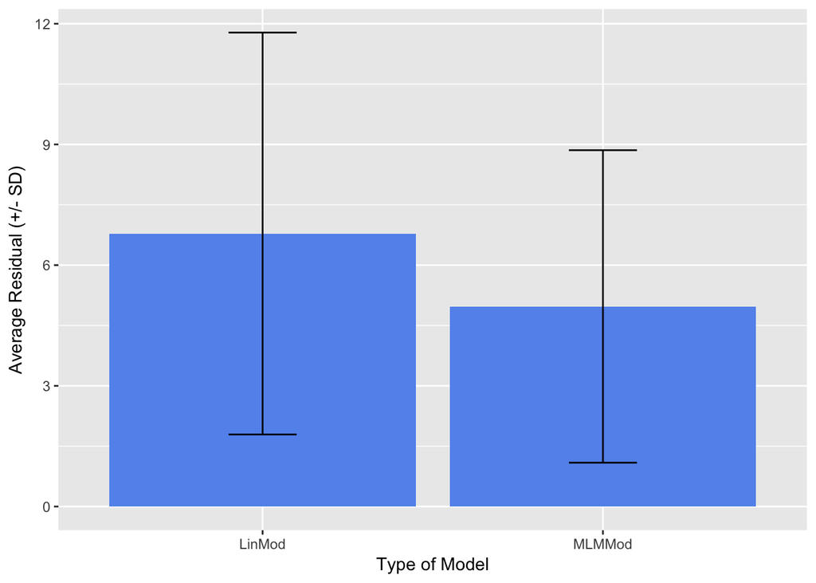

```r
mean.lin <- mean(lin.aug)
sd.lin <- sd(lin.aug)

dataframe <- data.frame("Type" = c("LinMod", "MLMMod"),
                        "Mean" = c(mean.lin, mean.mlm), "SD"= c(sd.lin, sd.mlm))

ResidPlot <- ggplot(dataframe, aes(Type, Mean)) +
                   geom_col(fill = "cornflowerblue") +
                   geom_errorbar(aes(ymin = Mean - SD, ymax = Mean + SD), width=0.2)
ResidPlot + labs(y="Average Residual (+/- SD)", x = "Type of Model")
```

Fixed effects: average intercept = 38.72 correct words  
Slope = 0  
ICC = .49  
Residual variance = 52.95

Residual variance (i.e., variance not accounted for by model) is much samller in the mixed-effect model compared to the linear model (Item 1), even though linear model uses age as a predictor whereas MLM model does not. ___

## Item 3: Introduce a fixed slope term. What is the difference in terms of the fixed effects estimates between this estimate and the previous? Of the residual standard error? Create a graph to show both fixed effects estimates and the CIs around them.

```r
library(MuMIn)
lin.mlm <- lmer(Sem_TotalCorrect ~ age.centered + (1 | ID2), data = wide_to_long_merged)
summary(lin.mlm)
```

```
## Linear mixed model fit by REML ['lmerMod']
## Formula: Sem_TotalCorrect ~ age.centered + (1 | ID2)
##    Data: wide_to_long_merged
##
## REML criterion at convergence: 1386.3
##
## Scaled residuals:
##      Min       1Q   Median       3Q      Max
## -1.98811 -0.56813 -0.06286  0.52471  3.13822
##
## Random effects:
##  Groups   Name        Variance Std.Dev.
##  ID2      (Intercept) 32.17    5.672
##  Residual             40.32    6.350
## Number of obs: 200, groups:  ID2, 67
##
## Fixed effects:
##              Estimate Std. Error t value
## (Intercept)   39.6212     0.8325    47.6
## age.centered   1.8619     0.2140     8.7
##
## Correlation of Fixed Effects:
##             (Intr)
## age.centerd 0.126
```

```r
lin.mlm.ci <- confint(lin.mlm, level = .95, oldNames = F)
```

```
## Computing profile confidence intervals ...
```

```r
lin.mlm.ci
```

```
##                        2.5 %    97.5 %
## sd_(Intercept)|ID2  4.256908  7.129394
## sigma               5.645588  7.191634
## (Intercept)        37.988937 41.260315
## age.centered        1.438460  2.286089
```

```r
summary1 <- broom::tidy(lin.mlm)
r.squaredGLMM(lin.mlm)
```

```
##       R2m       R2c
## 0.3399443 0.6328833
```

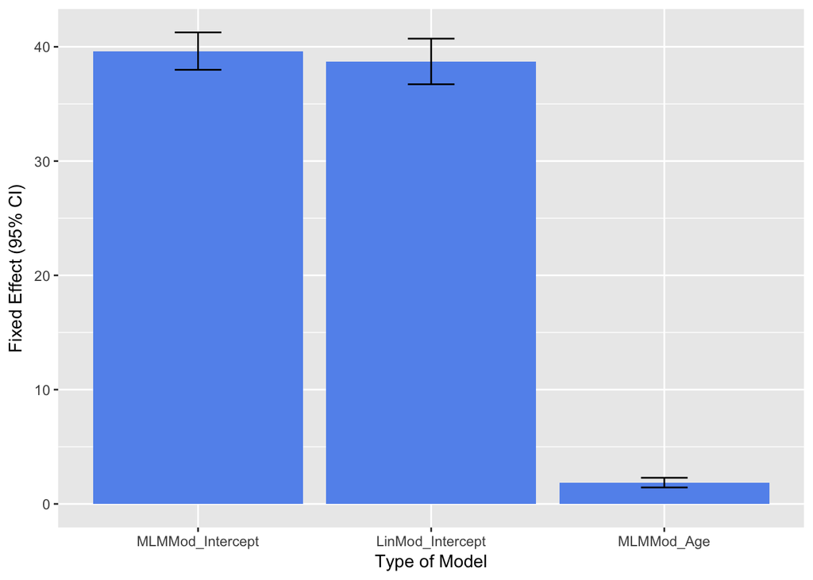

```r
#Graphing fixed effects
dataframe <- data.frame("Type" = c("LinMod_Intercept", "MLMMod_Intercept", "MLMMod_Age"),
                        "Mean" = c(38.72, summary1[1,2], summary1[2,2]),
                        "CILower"= c(lin.mlm.ci1[3,1], lin.mlm.ci[3,1], lin.mlm.ci[4,1]),
                        "CIUpper" = c(lin.mlm.ci1[3,2], lin.mlm.ci[3,2], lin.mlm.ci[4,2]))

FixedPlot <- ggplot(dataframe, aes(x = reorder(Type, -Mean), Mean)) +
                   geom_col(fill = "cornflowerblue") +
                   geom_errorbar(aes(ymin = CILower, ymax = CIUpper), width=0.2)
FixedPlot + labs(y="Fixed Effect (95% CI)", x = "Type of Model")
```

Fixed effects: average intercept = 39.62 correct words at mean age  
Fixed effects: average slope = 1.86 correct words/year  
Residual variance = 40.32  
Residual standard error = 6.35  
Psuedo R2 fixed = .34  
Pseudo R2 fixed + random = .63

## Item 4: Run an additional model with a random slope. How does this change compare to the previous model? Should you keep the random slope or not?

```r
lin.mlm <- lmer(Sem_TotalCorrect ~ age.centered + (age.centered | ID2), data = wide_to_long_merged)
summary(lin.mlm)
```

```
## Linear mixed model fit by REML ['lmerMod']
## Formula: Sem_TotalCorrect ~ age.centered + (age.centered | ID2)
##    Data: wide_to_long_merged
##
## REML criterion at convergence: 1381.7
##
## Scaled residuals:
##     Min      1Q  Median      3Q     Max
## -1.9380 -0.5849 -0.0708  0.4632  3.2995
##
## Random effects:
##  Groups   Name         Variance Std.Dev. Corr
##  ID2      (Intercept)  30.9260  5.5611
##           age.centered  0.7509  0.8665   0.45
##  Residual              37.3791  6.1138
## Number of obs: 200, groups:  ID2, 67
##
## Fixed effects:
##              Estimate Std. Error t value
## (Intercept)   40.0957     0.8712   46.02
## age.centered   2.0512     0.2504    8.19
##
## Correlation of Fixed Effects:
##             (Intr)
## age.centerd 0.360
```

```r
anova(lin.mlm)
```

```
## Analysis of Variance Table
##              Df Sum Sq Mean Sq F value
## age.centered  1 2507.2  2507.2  67.074
```

```r
r.squaredGLMM(lin.mlm)
```

```
##       R2m       R2c
## 0.3786386 0.6876268
```

Fixed effects: average intercept = 40.10 correct words at mean age  
Fixed effects: average slope = 2.05 words/year  
Residual variance = 37.38  
Pseudo R2 fixed = .38  
Pseudo R2 fixed + random = .69

## Item 5: Interpret the correlation between the slope and the intercept.

The fixed effects correlation = .36. This suggests a medium-sized relationship between the average intercept and the average slope wherein greater intercepts (i.e., more words correct) are associated with steeper slopes (i.e., faster rate of improvement in words correct). However, this association is not so large so as to be redundant. The random effects correlation (r = .45) models the relationship between intercept and slope on the individual level, designating the correlation between an individual’s deviation from the average intercept and their deviation from the average slope.  
___

## Item 6: Create a density plot of the random effects from your final model.

```r
library(merTools)
re.sim <- REsim(lin.mlm)
head(re.sim)
```

```
##   groupFctr groupID        term       mean     median       sd
## 1       ID2   10588 (Intercept)   4.807241  4.5822451 3.428993
## 2       ID2   16800 (Intercept)   1.266976  0.6541451 4.527456
## 3       ID2   17555 (Intercept)  -2.577477 -2.5227761 2.816827
## 4       ID2   17910 (Intercept)   3.447165  3.2381170 3.161266
## 5       ID2   18709 (Intercept)   2.578099  2.7239863 2.917462
## 6       ID2   22162 (Intercept) -10.021278 -9.9844694 3.041339
```

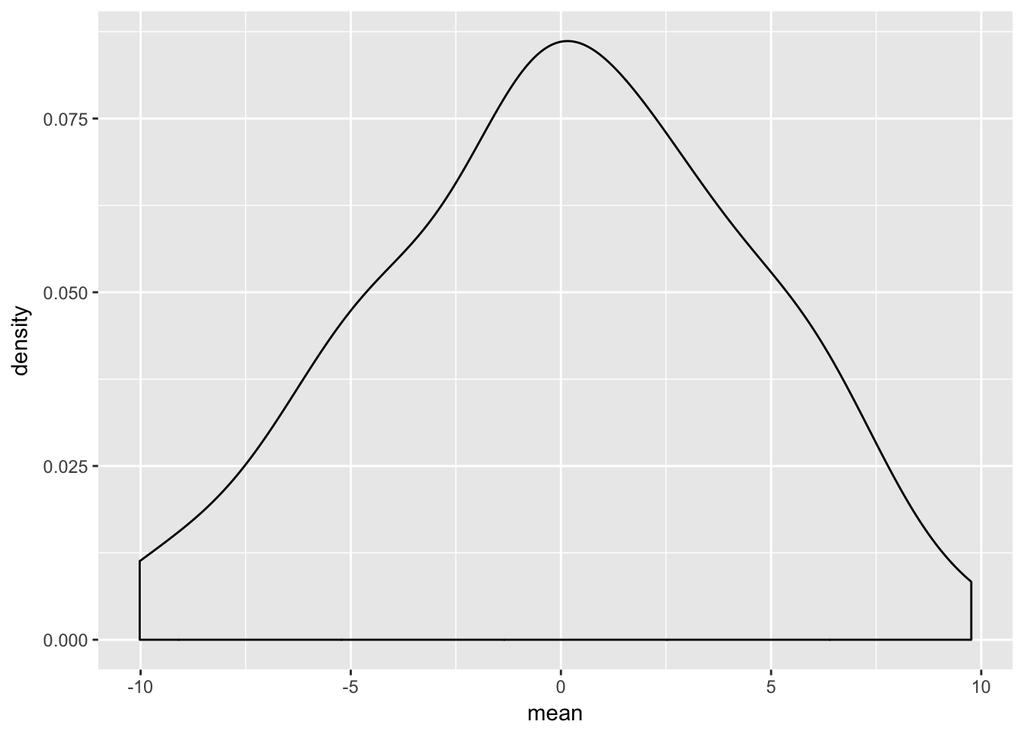

```r
#Density Intercept
graph1 <- re.sim %>%
  filter(term == "(Intercept)")
ggplot(graph1, aes(mean)) +
  geom_density()
```

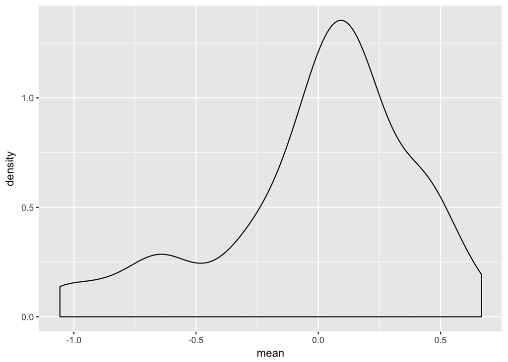

```r
#Density age
graph2 <- re.sim %>%
  filter(term == "age.centered")
ggplot(graph2, aes(mean)) +
  geom_density()
```

## Item 7: Create a catepilar plot of the random effects. Is there any person that seems odd in terms of a large standard errors around intercept and slope estimates?

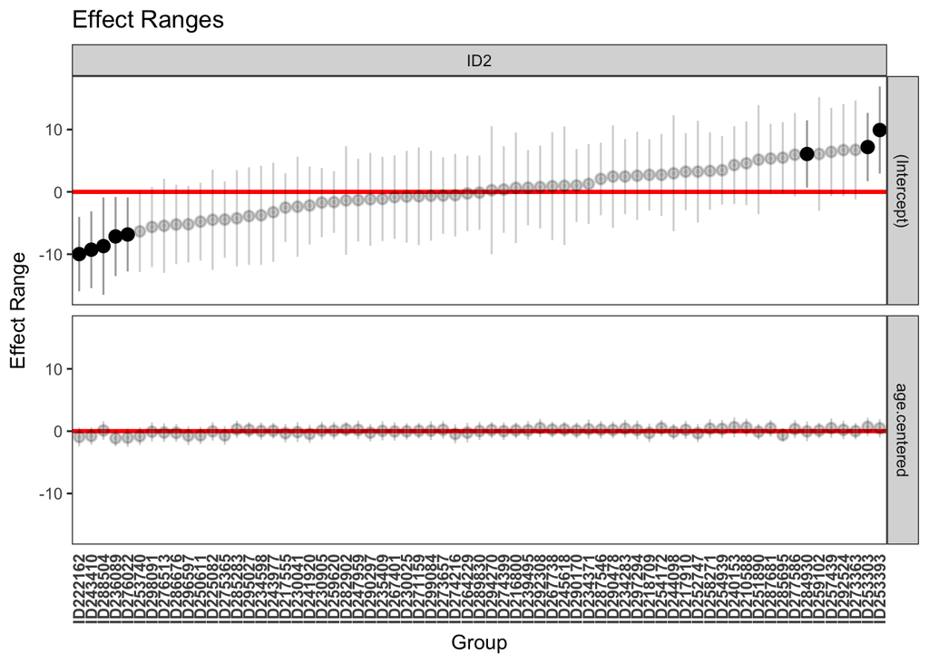

```r
graph3 <- plotREsim(re.sim, labs = T)
graph3
```

## Item 8: Create a plot of the trajectory, along with a spaghetti plot of each person’s individual slope. Set the alpha level (transparency) on the individual slopes to make them easier to see.

```r
Predict <- predictInterval(merMod = lin.mlm, newdata = wide_to_long_merged, level = 0.9, n.sims = 100,
                           stat = "median", include.resid.var = TRUE)
head(Predict)
```

```
##        fit      upr      lwr
## 1 58.20110 69.87762 46.74563
## 2 62.06936 73.61755 49.55347
## 3 30.63350 42.79713 20.24218
## 4 33.94263 46.57712 20.84580
## 5 35.40699 45.24995 26.98414
## 6 44.37027 55.96112 32.21745
```

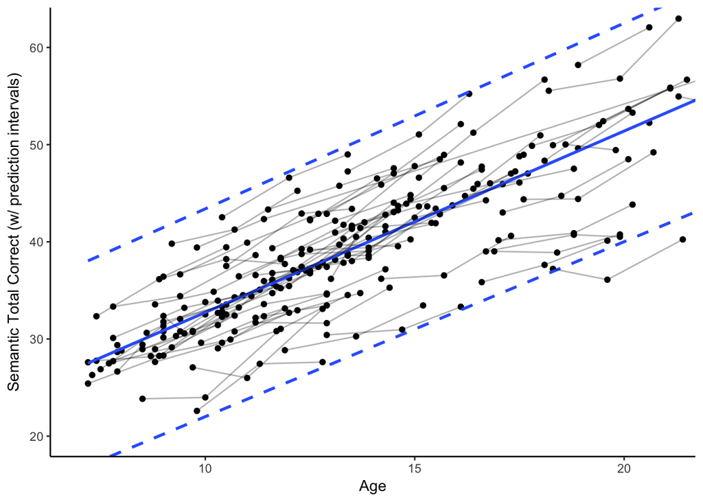

```r
wide_to_long_merged$fit <- Predict$fit
wide_to_long_merged$upr <- Predict$upr
wide_to_long_merged$lwr <- Predict$lwr

wide_to_long_merged$Age_years <- as.numeric(wide_to_long_merged$Age_years)

ggplot(aes(x=Age_years, y=fit), data=wide_to_long_merged) +
  geom_point() +
  stat_smooth(method = lm, se = F) +
  labs(x="Age", y="Semantic Total Correct (w/ prediction intervals)") + theme_bw() +
  stat_smooth(aes(x = Age_years, y = upr), method = lm, se = F, alpha = .3, linetype = "dashed") +
  stat_smooth(aes(x = Age_years, y = lwr), method = lm, se = F, alpha = .3, linetype = "dashed")+
  geom_line(data = wide_to_long_merged, aes(x = Age_years, y = fit, group=ID2), alpha = .3) +
  coord_cartesian(xlim = c(7,21), ylim = c(20,62)) +
  theme_classic()
```